# Application of Reinforcement Learning on Autonomous Driving Agents

## Introduction

In this project, we work towards constructing an optimized Q-Learning driving agent that navigates a *Smartcab* through its environment towards a goal. Since the *Smartcab* is expected to drive passengers from one location to another, the driving agent is evaluated on two fundamental metrics: **Safety** and **Reliability**. A driving agent that gets the *Smartcab* to its destination while running red lights or narrowly avoiding accidents would be considered **unsafe**. Similarly, a driving agent that frequently fails to reach the destination in time would be considered **unreliable**. Maximizing the driving agent's **safety** and **reliability** would ensure that *Smartcabs* have a permanent place in the transportation industry.

**Safety** and **Reliability** are measured using a letter-grade system as follows:

| Grade | Safety | Reliability |
| --- | --- | --- |
| A+ | Agent commits no traffic violations, and always chooses the correct action. | Agent reaches the destination in time for 100% of trips. |
| A | Agent commits few minor traffic violations, such as failing to move on a green light. | Agent reaches the destination on time for at least 90% of trips. |
| B | Agent commits frequent minor traffic violations, such as failing to move on a green light. | Agent reaches the destination on time for at least 80% of trips. |
| C | Agent commits at least one major traffic violation, such as driving through a red light. | Agent reaches the destination on time for at least 70% of trips. |
| D | Agent causes at least one minor accident, such as turning left on green with oncoming traffic. | Agent reaches the destination on time for at least 60% of trips. |
| F | Agent causes at least one major accident, such as driving through a red light with cross-traffic. | Agent fails to reach the destination on time for at least 60% of trips. |

## Implement a Basic Driving Agent

The first step to creating an optimized Q-Learning driving agent is getting the agent actually to take valid actions. In this case, a valid action is one of `None`, (do nothing) `'left'` (turn left), `right'` (turn right), or `'forward'` (go forward). For the first implementation, we will allow the agent to choose one of these actions randomly.

We can do this by setting the `choose_action(self, state)` function in `agent.py` as follows:

```
def choose_action(self, state):
        """ The choose_action function is called when the agent is asked to choose
            which action to take, based on the 'state' the smartcab is in. """

        # Set the agent state and default action
        self.state = state
        self.next_waypoint = self.planner.next_waypoint()

        # Choose a random action
        return random.choice(self.valid_actions)
```

### Basic Agent Simulation Results

To obtain results from the initial simulation, we need to adjust the following flags:

- `'enforce_deadline'` - to `True` to force the driving agent to capture whether it reaches the destination in time.
- `'update_delay'` - to a small value (such as `0.01`) to reduce the time between steps in each trial.
- `'log_metrics'` - to `True` to log the simulation results as a `.csv` file in `/logs/`.
- `'n_test'` - to `'10'` to perform 10 testing trials.

Optionally, we can disable the visual simulation (which can make the trials go faster) by setting the `'display'` flag to `False`.

Once we have completed the initial simulation we can visualize the results.

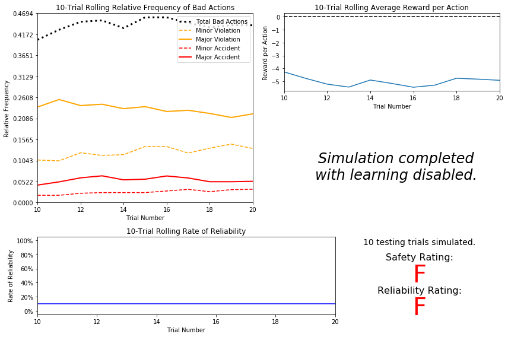

## Inform the Driving Agent

The second step to creating an optimized Q-learning driving agent is defining a set of states that the agent can occupy in the environment. Depending on the input, sensory data, and additional variables available to the driving agent, a set of states can be defined for the agent so that it can eventually *learn* what action it should take when occupying a state. The condition of `'if state then action'` for each state is called a **policy**, and is ultimately what the driving agent is expected to learn. Without defining states, the driving agent would never understand which action is most optimal or even what environmental variables and conditions it cares about!

### Identify States

Inspecting the `'build_state()'` agent function shows that the driving agent is given the following data from the environment:

- `'waypoint'`, which is the direction the *Smartcab* should drive leading to the destination, relative to the *Smartcab*'s heading.
- `'inputs'`, which is the sensor data from the *Smartcab*. It includes
  - `'light'`, the color of the light.
  - `'left'`, the intended direction of travel for a vehicle to the *Smartcab*'s left. Returns `None` if no vehicle is present.
  - `'right'`, the intended direction of travel for a vehicle to the *Smartcab*'s right. Returns `None` if no vehicle is present.
  - `'oncoming'`, the intended direction of travel for a vehicle across the intersection from the *Smartcab*. Returns `None` if no vehicle is present.
- `'deadline'`, which is the number of actions remaining for the *Smartcab* to reach the destination before running out of time.

From the features available some are more relevant for learning both **safety** and **efficiency** to the agent. `waypoint` and `input` are probably the most relevant:

- `waypoint`: is the key feature of efficiency. It gives the agent the direction of the destination. Without it, the agent will roam in random directions and most probably will never get to the destination.
- `inputs`: make the agent aware of the environment and protect it from committing traffic violations. Especially `left`, and `oncoming` have a higher value because they protect the agent from committing accidents.

`deadline` cannot be considered as a relevant feature because it provides info that does not change the actions of the agent.

### Define a State Space

When defining a set of states that the agent can occupy, it is necessary to consider the *size* of the state space. That is to say, if we expect the driving agent to learn a **policy** for each state, we would need to have an optimal action for *every* state the agent can occupy. If the number of all possible states is very large, it might be the case that the driving agent never learns what to do in some states, which can lead to uninformed decisions. For example, consider a case where the following features are used to define the state of the *Smartcab*:

`('is_raining', 'is_foggy', 'is_red_light', 'turn_left', 'no_traffic', 'previous_turn_left', 'time_of_day')`.

How frequently would the agent occupy a state like `(False, True, True, True, False, False, '3AM')`? Without a near-infinite amount of time for training, it's doubtful the agent would ever learn the proper action!

In our case the features that define the state of the Smartcab are:  
`('inputs/light', 'waypoint', 'inputs/direction')`  
if we add the state of each feature we have:

| Feature | States |
| --- | --- |
| inputs/light | green, red |
| waypoint | forward, left, right |
| input/left | forward, left, right, None |
| input/oncoming | forward, left, right, None |

As you may notice, we omitted the input/right. This is because the agent cannot collide with a right coming car. When the agent has a green light, they have to give way and when they have green light, the agent can only turn right. The above States create a space of size 2x3x4x4 = 96.  
This size is small enough for an agent to learn within a reasonable number of training trials.

### Update the Driving Agent State

We will use the above State Space to to update the state of the Agent. The Agent's state will be defined in `build_state` function as a tuple that describes the current state.

```
state = (waypoint, inputs['light'], inputs['oncoming'], inputs['left'])
```

## Implement a Q-Learning Driving Agent

The third step to creating an optimized Q-Learning agent is to begin implementing the functionality of Q-Learning itself. The concept of Q-Learning is fairly straightforward: For every state the agent visits, we should create an entry in the Q-table for all state-action pairs available. Then, when the agent encounters a state and performs an action, we should update the Q-value associated with that state-action pair based on the reward received and the iterative update rule implemented. Of course, additional benefits come from Q-Learning, such that we can have the agent choose the *best* action for each state based on the Q-values of each state-action pair possible. For this project, we are implementing a *decaying,* $\epsilon$*-greedy* Q-learning algorithm with *no* discount factor.

Note that the agent attribute `self.Q` is a dictionary: This is how the Q-table will be formed. Each state will be a key of the `self.Q` dictionary, and each value will then be another dictionary that holds the *action* and *Q-value*. Here is an example:

```
{ 'state-1': {
    'action-1' : Qvalue-1,
    'action-2' : Qvalue-2,
     ...
   },
  'state-2': {
    'action-1' : Qvalue-1,
     ...
   },
   ...
}
```

Furthermore, note that since we are implementing a *decaying* $\epsilon$ *(exploration) factor*, as the number of trials increases, $\epsilon$ should decrease towards 0. This is because the agent is expected to learn from its behavior and begin acting on its learned behavior. Additionally, The agent will be tested on what it has learned after $\epsilon$ has passed a certain threshold (the default threshold is 0.05). For the initial Q-Learning implementation, we are implementing a linear decaying function for $\epsilon$.

$$\epsilon_{t+1} = \epsilon_{t} - 0.05, \ \ \ \ \ \ \ \textrm{for trial number }t$$

### Q-Learning Simulation Results

To obtain results from the initial Q-Learning implementation, we need to adjust the following flags and setup:

- `'enforce_deadline'` - to `True` to force the driving agent to capture whether it reaches the destination in time.
- `'update_delay'` - to a small value (such as `0.01`) to reduce the time between steps in each trial.
- `'log_metrics'` - to `True` to log the simulation results as a `.csv` file and the Q-table as a `.txt` file in `/logs/`.
- `'n_test'` - to `'10'` to perform 10 testing trials.
- `'learning'` - to `'True'` to tell the driving agent to use our Q-Learning implementation.

The number of additions we had to make to the `agent.py` are a lot to mention here. The most significant change from the final `agent.py` (provided in the repository) is the use of the above decay function in the `def reset()` function.

Once we have completed the initial simulation, we can visualize the results again.

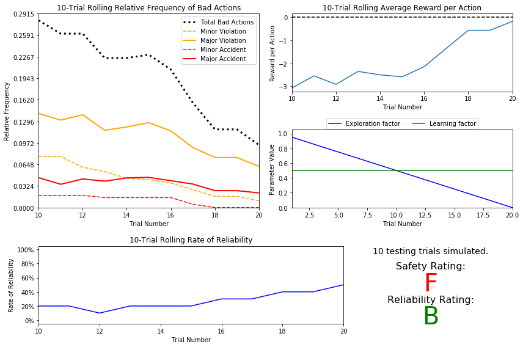

Using the visualization above that was produced from the simulation we notice that:

- This time the agent performs significantly better. It starts with a ratio of wrong actions around 1/3 and gradually it falls to 1/10.
- The agent needs 20 training trials before testing. Since epsilon starts at the value of 1 and it gets decreased by 0.05 on each trial, this is an expected value.
- The decay function is represented accurately in the parameters panel. It starts at 1 and decreases linearly to zero.
- As the number of trials increases, the Exploration Factor decreases leading the agent to decide more frequently based on "past knowledge". Also, the Q-table is populated with more action-value pairs increasing the probability of taking the best action. As a result, the number of wrong actions decrease and the average reward increases.
- The safety rating remains the same. It seems that even the agent performs better it still makes many accidents and violations. On the other hand, the reliability has increased from F to B.

## Improve the Q-Learning Driving Agent

The third step to creating an optimized Q-Learning agent is to perform the optimization! Now that the Q-Learning algorithm is implemented and the driving agent is successfully learning, it's necessary to tune settings and adjust learning paramaters so the driving agent learns both **safety** and **efficiency**. Typically this step will require a lot of trial and error, as some settings will invariably make the learning worse. One thing to keep in mind is the act of learning itself and the time that this takes: In theory, we could allow the agent to learn for an incredibly long amount of time; however, another goal of Q-Learning is to *transition from experimenting with unlearned behavior to acting on learned behavior*. For example, always allowing the agent to perform a random action during training (if $\epsilon = 1$ and never decays) will certainly make it *learn*, but never let it *act*.

### Improved Q-Learning Simulation Results

To obtain results from the Q-Learning implementation, we need to adjust the following flags and setup:

- `'enforce_deadline'` - to `True` to force the driving agent to capture whether it reaches the destination in time.
- `'update_delay'` - to a small value (such as `0.01`) to reduce the time between steps in each trial.
- `'log_metrics'` - to `True` to log the simulation results as a `.csv` file and the Q-table as a `.txt` file in `/logs/`.
- `'learning'` - to `'True'` to tell the driving agent to use your Q-Learning implementation.
- `'optimized'` - to `'True'` to tell the driving agent you are performing an optimized version of the Q-Learning implementation.

Additionally, the results presented bellow have been achieved by using the following values in Agent's flags:

- `'n_test'` = 10
- `'alpha'` = 0.7
- `'epsilon'` = 1
- `'tolerance'` = 0.00001

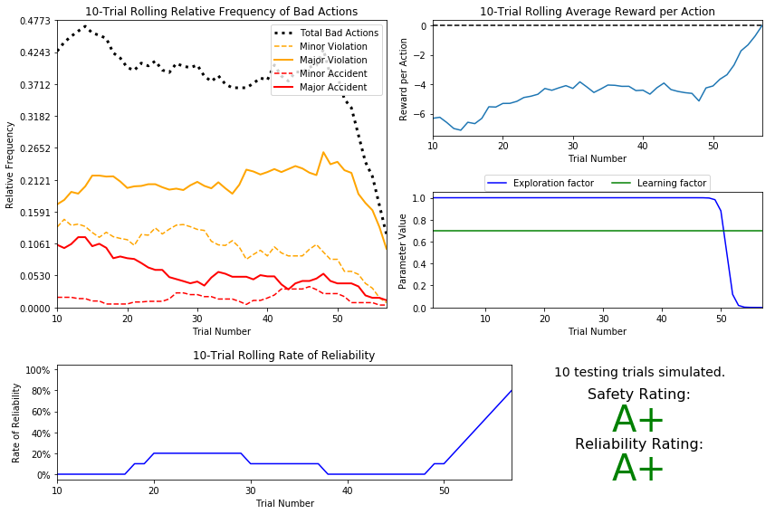

As a decay function we crafted a custom function inspired by the sigmoid function. Our goal was to create a function that during learning allow the agent to explore all possible actions in order to populate a Q-table with as many actions as possible. Then drop quickly the Exploration Factor before start testing to use the gathered knowledge.

[figure not shown]

where 'p' is a parameter that adjust the position of the function on the X axis, thus adjusts the number of trials that will be used for training. We were be able to achieve top rated score for p=50.

An interesting observation is how quick the agent learns. With the suggested decay function the agent needs less than 60 trials before beginning testing.

Trying different parameters we achieved the best results with a learning rate of 0.7. For the epsilon-tolerance, we had to use a tiny number (0.00001) since the Exploration Factor was converging very fast to 0.

## Conclusion

#### Notes

- Adapted from a reinforcement learning assignement during my study for Udacity's [Machine Learning Engineer NanoDegree](https://www.udacity.com/course/machine-learning-engineer-nanodegree--nd009t)
- The starter code provided by Udacity and can be found on [this](https://github.com/udacity/machine-learning/tree/master/projects/smartcab) GitHub repository.